# Stat 579 - Homework #7 - Section B

10/15/2019

## Chick Weights

For this assignment we will use the data set `ChickWeight`. You need to load the data in R using `data(ChickWeight)`. The `ChickWeight` data frame has 578 rows and 4 columns from an experiment on the effect of diet on early growth of chicks. Use `?ChickWeight` to get more information on every one of the variables.

1. Download the RMarkdown file with these homework instructions to use as a template for your work. Make sure to replace “Your Name” in the YAML with your name.
2. Each chick should have twelve weight measurements. Use the `dplyr` package to identify how many chicks have a complete set of weight measurements and how many measurements there are in the incomplete cases. Extract a subset of the data for all chicks with complete information and name the data set `complete`. (Hint: you might want to use `mutate` to introduce a helper variable consisting of the number of observations)

```r
library(tidyverse)
ChickWeight %>%
  group_by(Chick,Diet) %>%
  summarise(n = n()) %>%
  arrange(n)
```

```
## # A tibble: 50 x 3
## # Groups:   Chick [50]
##    Chick Diet      n
##    <ord> <fct> <int>
##  1 18    1         2
##  2 16    1         7
##  3 15    1         8
##  4 44    4        10
##  5 8     1        11
##  6 13    1        12
##  7 9     1        12
##  8 20    1        12
##  9 10    1        12
## 10 17    1        12
## # … with 40 more rows
```

```r
Complete <-filter(ChickWeight, Chick!= 18 & Chick!=16 &  Chick!=15 & Chick != 44 & Chick != 8)
```

There are 50 chicks and five of them have incomplete observations. chick #18 only has 2 observations, #16 has 7, #15 has 8, #8 has 11 observations and #44 has 10 observations.

3. In the `complete` data set introduce a new variable that measures the current weight difference compared to day 0. Name this variable `weightgain`.

```r
Complete <- Complete  %>% group_by(Chick) %>% mutate(
  weightgain= (weight)- (weight [Time==0])
)

head(Complete)
```

```
## # A tibble: 6 x 5
## # Groups:   Chick [1]
##   weight  Time Chick Diet  weightgain
##    <dbl> <dbl> <ord> <fct>      <dbl>
## 1     42     0 1     1              0
## 2     51     2 1     1              9
## 3     59     4 1     1             17
## 4     64     6 1     1             22
## 5     76     8 1     1             34
## 6     93    10 1     1             51
```

4. Using the `ggplot2` package create side-by-side boxplots of `weightgain` by `Diet` for day 21. Describe the relationship in 2-3 sentences. Change the order of the categories in the `Diet` variable such that the boxplots are ordered by median `weightgain`.

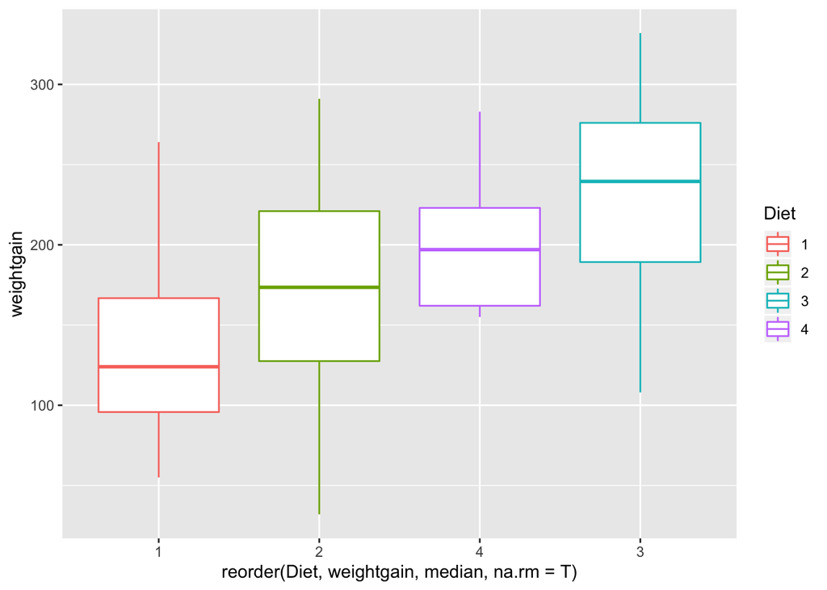

```r
Complete  %>% filter(Time ==21) %>%
  ggplot(aes (x=reorder (Diet, weightgain, median, na.rm=T), y= weightgain, color = Diet)) +
  geom_boxplot()
```

Diet three has the highest weight gain by day 21. You can also note that diets 2 and 3 have an approximate nirmal distribution wuile diets 1 and 4 show some skewness.

5. Draw a plot of weight by time. Facet by `Diet`. Use a point layer and also draw one line for each `Chick` (use `geom_line` and specify `group = Chick`). Color by `Diet`.  
   Comment on the plot in 2-3 sentences.

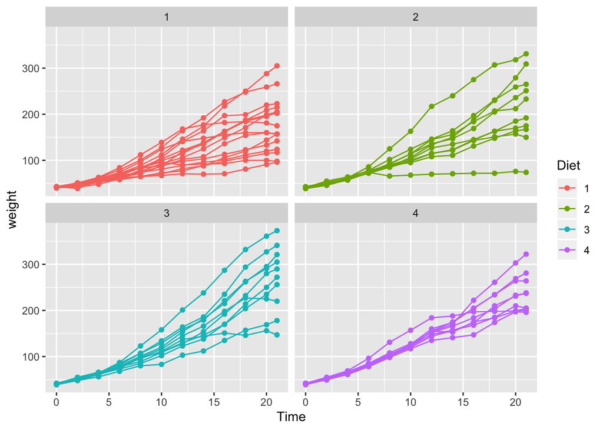

```r
Complete %>%
  ggplot(aes(x=Time, y=weight, color = Diet)) +
geom_point() +
geom_line(aes(group = Chick)) +
  facet_wrap(~Diet)
```

There are clear differences between the max weight reach by the chicks in each diet. It is also very noticable the wide difference of finals weights within diet.

6. Comment on the two resulting plots below. Which plot best describes the effect of the diets on the chicks?
1. Select the `Chick` with the maximum weight at `Time` 21 for each of the diets. Redraw the previous plot with only these 4 chicks (and don’t facet).

```r
Complete %>%
 filter(Time ==21) %>%
  filter(weight >= 300)
```

```
## # A tibble: 8 x 5
## # Groups:   Chick [8]
##   weight  Time Chick Diet  weightgain
##    <dbl> <dbl> <ord> <fct>      <dbl>
## 1    305    21 7     1            264
## 2    331    21 21    2            291
## 3    309    21 29    2            270
## 4    305    21 32    3            264
## 5    341    21 34    3            300
## 6    373    21 35    3            332
## 7    321    21 40    3            280
## 8    322    21 48    4            283
```

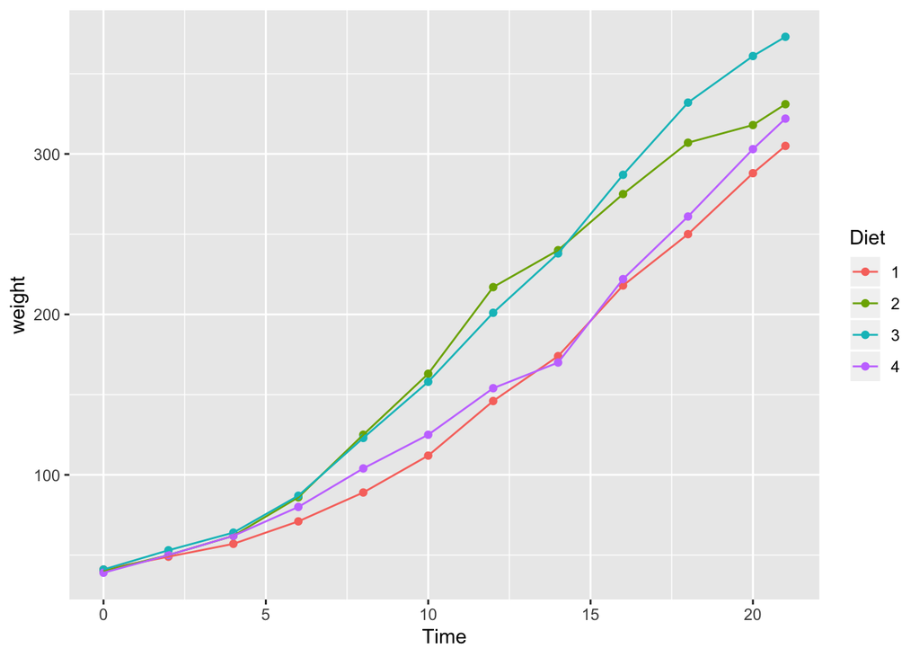

```r
Complete %>%
  filter(Chick== 7 | Chick ==21 | Chick == 35 | Chick == 48) %>%
  ggplot(aes(x=Time, y=weight, color = Diet)) +
geom_point() +
geom_line()
```

b. Compute average daily weights under each Diet and redraw the plot (using the same structure and aesthetics as before).

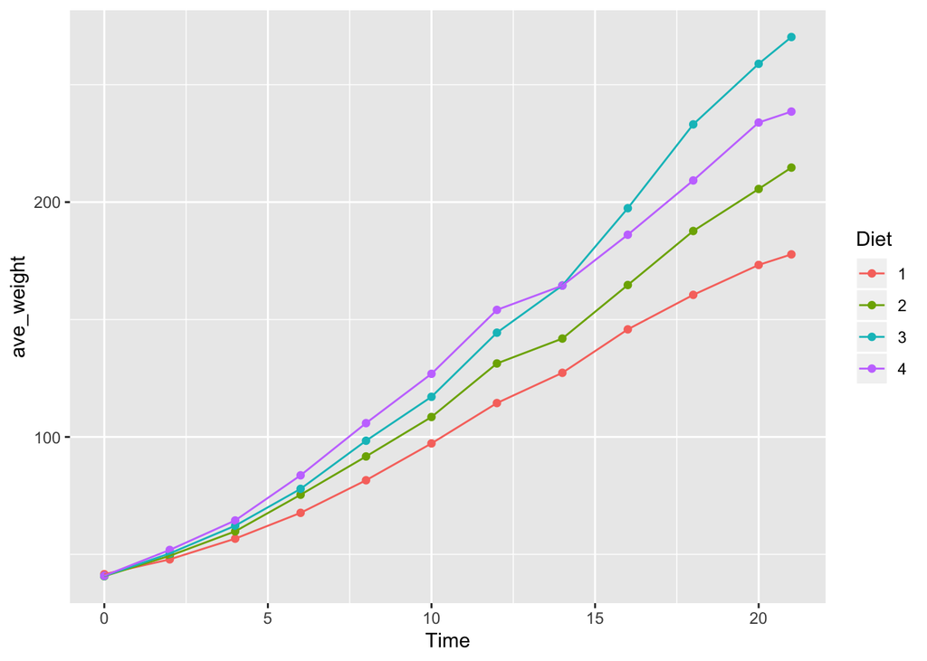

```r
  Complete %>%
  group_by(Diet,Time) %>%
  summarise(
    ave_weight = mean(weight)
  ) %>%
  ggplot(aes(x=Time, y=ave_weight, color = Diet)) +
  geom_point() +
  geom_line()
```

The effect of diet is best explained by graph B, it takes in consideration the effects of all the chicks in each group instead of biasing the results by using only the chick that gained the most weight.

Due date: please refer to the website and Canvas for the due date.

For the submission: submit your solution in an R Markdown file and (just for insurance) submit the corresponding html/word file with it.